# Question 4 — Netflix: what works in streaming

Student 25052977

19 June 2026

## The brief

A team thinking about launching a streaming service wants a quick read on what sits on Netflix and what rates well: the mix of content by country and type, the genres that dominate, how titles score, how long movies run, and what the catalogue is “about”.

## What’s on the platform

Movies vs shows

| type | titles |
| --- | --- |
| MOVIE | 3759 |
| SHOW | 2047 |

Top production countries by number of titles

| country | titles |
| --- | --- |
| US | 2327 |
| IN | 629 |
| GB | 406 |
| JP | 291 |
| FR | 248 |
| CA | 216 |
| KR | 216 |
| ES | 212 |
| DE | 139 |
| MX | 123 |

The catalogue is mostly films, and heavily US-led, with India, the UK, Japan and South Korea making up most of the rest. For a new entrant that says the obvious markets are crowded, and that Korean and Japanese content is a meaningful slice worth watching.

## Which genres dominate, and do they rate well?

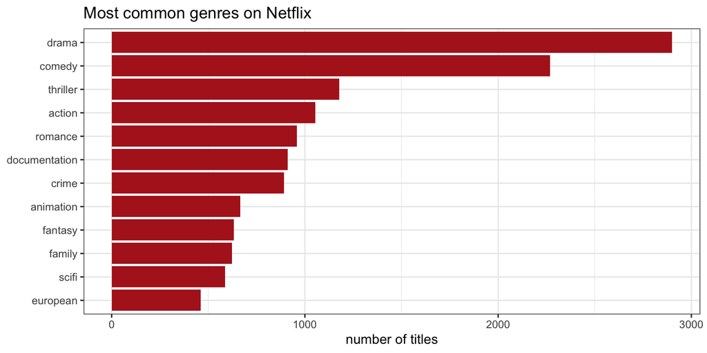

Genre counts and average IMDb score

| genre | titles | avg_imdb |
| --- | --- | --- |
| drama | 2901 | 6.66 |
| comedy | 2269 | 6.42 |
| thriller | 1178 | 6.36 |
| action | 1053 | 6.46 |
| romance | 958 | 6.44 |
| documentation | 910 | 7.04 |
| crime | 891 | 6.68 |
| animation | 665 | 6.73 |
| fantasy | 631 | 6.58 |
| family | 622 | 6.34 |
| scifi | 587 | 6.58 |
| european | 460 | 6.54 |

## How do titles rate?

IMDb rating by type

| type | n | median_imdb | mean_imdb |
| --- | --- | --- | --- |
| MOVIE | 3407 | 6.4 | 6.27 |
| SHOW | 1876 | 7.2 | 7.02 |

[figure not shown]

Shows tend to score slightly higher than movies, and the spread is wide for both: plenty of low-rated filler alongside the hits. A new service competing on quality could do well to be more selective than the “stock everything” approach.

## How long are the movies?

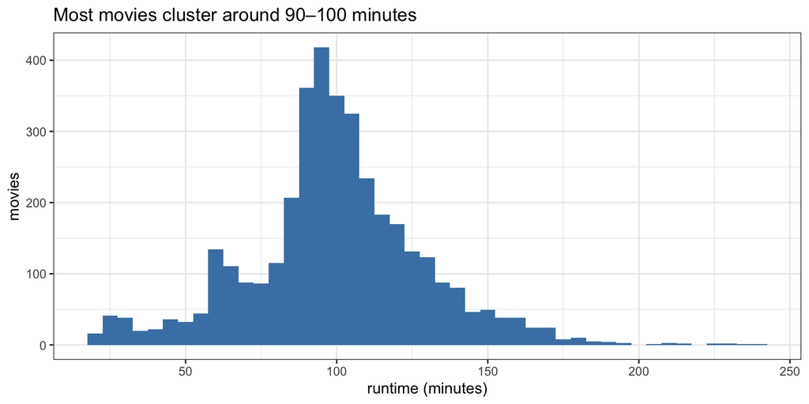

Movie length is tightly clustered around the standard 90–100 minute feature, tailing off past two hours. There’s little appetite on the platform for very short or very long films.

## What is the catalogue about?

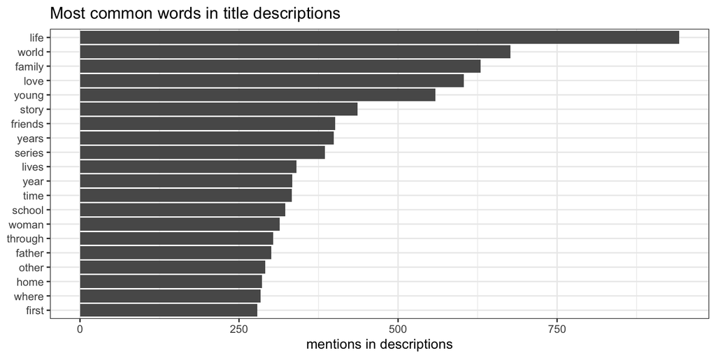

The descriptions lean on life, family, love, young and friends: the themes the platform keeps coming back to. Useful for a new service deciding what emotional territory to own.